# Coastal Queries : Investigating Optimal Locations for Marine Aquaculture along the United States West Coast

This blog post uses information regarding optimal oceanic conditions for common aquaculture species to identify which Economic Exclusive Zones along the United States’ West Coast are most suitable for establishing Marine Aquacultures

*Emma Cardoso* • *December 15, 2023*

### Research Question :

What are the optimal Economic Exclusive Zones (EEZ) off the United States’ West Coast for establishing marine aquacultures, and how do these zones vary in suitability for different species based on their temperature and depth preferences?

### Importance :

Delving into the realm of marine aquaculture, which encompasses the breeding, rearing, and harvesting of aquatic organisms, offers a glimpse into the vital role these systems play in shaping our food systems. Defined by the [National Oceanic and Atmospheric Administration](https://www.fisheries.noaa.gov/insight/marine-aquaculture#:~:text=Marine%20aquaculture%20provides%20a%20domestic,supports%20our%20wild%20fisheries%20production.) marine aquaculture is not merely a source of sustenance; it stands as a cornerstone for fostering domestic production and supporting our fisheries (5).

With seafood being a primary protein source for over 3 billion people globally, the United States finds itself importing over 60% of its seafood, resulting in a substantial deficit surpassing $16 billion (4). This scenario underscores the untapped potential of marine aquaculture to boost food production, unlock economic opportunities, invigorate local economies, and contribute to environmental stewardship by maintaining the cleanliness of our waterways. In the United States, marine aquaculture predominantly focus on oysters, mussels, shrimp, clams, salmon, and other marine species adept at thriving in the oceanic conditions off the U.S. coast (5). This presents a unique opportunity to explore and expand marine aquaculture initiatives to meet the growing demand for seafood.

Economic Exclusion Zones (EEZ), defined as regions where coastal nations exert jurisdiction over living and non-living resources, extend approximately 200 nautical miles beyond a nation’s territorial sea (6). Understanding and strategically utilizing these zones are crucial for shaping the future landscape of marine aquaculture.

This analysis embarks on a journey to identify the most suitable Economic Exclusive Zones off the West Coast of the United States for cultivating marine aquacultures, with a particular focus on oysters. These bivalve mollusks, known for their success in U.S. aquacultures, serve as ambassadors for the potential of sustainable and economically viable marine farming practices.

Beyond the scope of oysters, the project aspires to provide a versatile tool—a function allowing users to input specific survival conditions, such as sea surface temperatures and depths below sea level, for any aquatic species. The resulting output will unveil the optimal Economic Exclusive Zones along the West Coast for developing tailored marine aquacultures for various species. This tool will also be utilized to investigate EEZ suitability of Pacific Littleneck Clams, Leukoma staminea, as these Clams are popular choices for marine aquaculture, and have a wide distribution across the Pacific Ocean.

In essence, this exploration transcends the boundaries of a research endeavor. It’s a voyage into the future of sustainable and localized seafood production, echoing the broader call to harness the potential of our oceans for the greater benefit of food security, economic prosperity, and environmental well-being

### Data :

#### Sea Surface Temperatures

Using data originally generated from [NOAA’s 5km Daily Global Satellite Sea Surface Temperature Anomaly v3.1](https://coralreefwatch.noaa.gov/product/5km/index_5km_ssta.php) (3). This analysis will use the average annual sea surface temperatures (SST) from 2008-2012 to characterize the average sea surface temperatures within the area.

#### Bathymetry

For data regarding the depth of the ocean, data from [General Bathymetric Chart of the Oceans (GEBCO)](https://www.gebco.net/data_and_products/gridded_bathymetry_data/#area) will be utilized (1).

#### Economic Exclusive Zones

Maritime boundaries will be designated using Economic Exclusive Zones (EEZ) off the West Coast of the United States, where this data was collected from [Marineregions.org](https://www.marineregions.org/eez.php) (2).

### Basic Data Analysis :

In regards to oysters, it is known that oysters need the following conditions for optimal growth :

- sea surface temperature: 11-30°C
- depth: 0-70 meters below sea level

In order to fulfill my goal of identifying which Economic Exclusive Zones off the United State’s West Coast are best suited for creating oyster aquaculture, I first needed to identify which areas in the Pacific posses conditions that are optimal for oyster growth. This was achieved by combining information on sea surface temperatures from NOAA (3) from 2008-2012 to identify mean sea surface temperatures. Using information on the optimal conditions for oyster growth, I reclassified this data in order to determine which areas in the Pacific were suitable for oysters. I did this same reclassification on the depth data using the optimal oyster depth range. Upon determining areas in the Pacific that had suitable sea surface temperatures and areas that had suitable depth, I combined the two datasets to identify locations that satisfied both sea surface temperature and depth conditions for oysters.

Upon identifying suitable locations for oysters based upon their optimal oceanic conditions, I then the shapefile outlining the different Economic Exclusive Zones off of the US West Coast to extract the suitable oyster area locations for each EEZ. After identifying the amount of suitable oyster area associated with each EEZ region, I performed calculations to determine the total suitable oyster area and the percent suitable oyster area for each EEZ. These output of these calculations was then mapped to visualize the results, thereby allowing for systematic ranking of Economic Exclusive Zones by priority regarding the implementation of potential oyster marine aquacultures.

As the importance of increasing the amount of established marine aquacultures in the United States is evident, it is imperative that multiple aquaculture species are considered, not just oysters. Thus, I created a function in which users would be able to input the species name and their optimal sea surface temperature and depth range, and the output would generate maps depicting the total suitable area and percent suitable area for the different west coast EEZ regions. This in turn allows for informed prioritization regarding where to establish marine aquacultures on the United State’s Pacific coast depending on the species. I ran this function for Pacific Littleneck Clams, Leukoma staminea, as their wide distribution across the Pacific Ocean make these species popular candidates for marine aquaculture.

### Data Visualization :

#### Mapping West Coast EEZ Oyster Marine Aquaculture Suitability

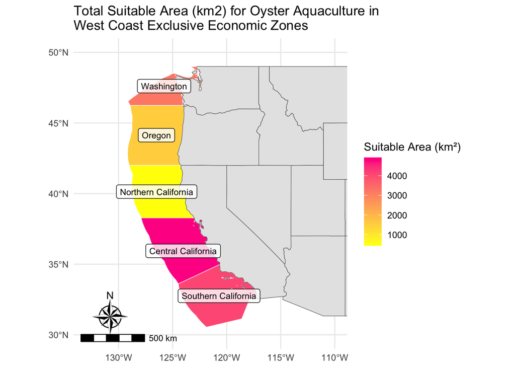

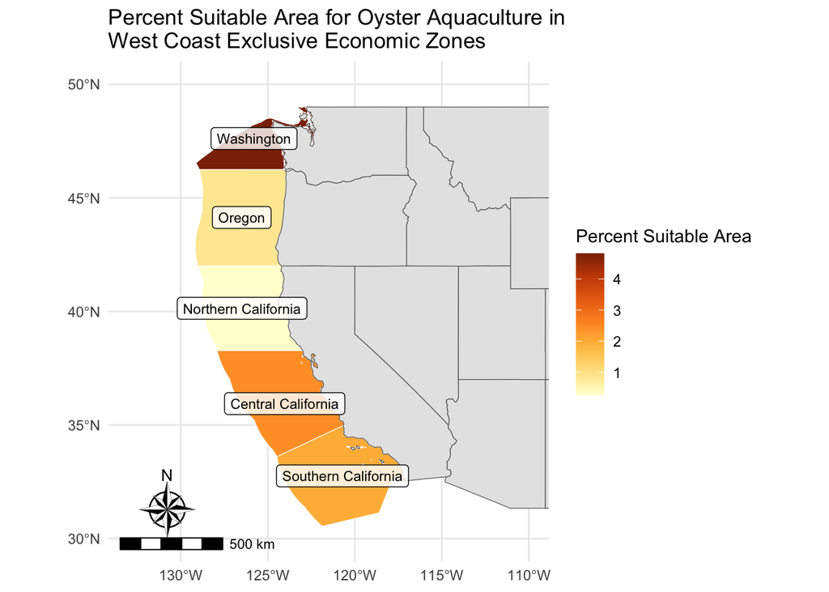

#### Running Function to Map West Coast EEZ Pacific Littleneck Clam Marine Aquaculture Suitability

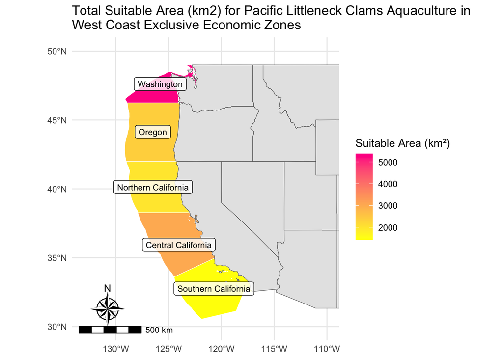

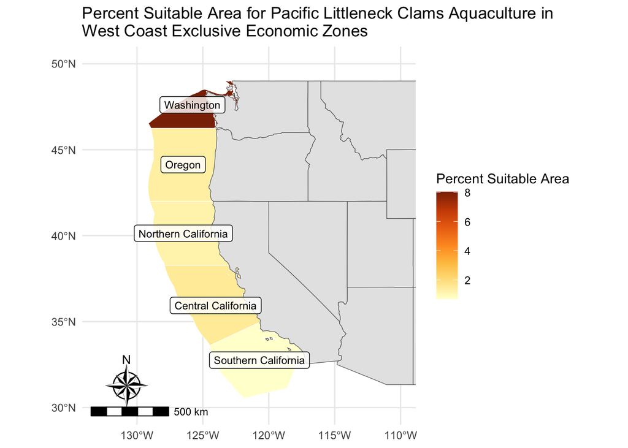

### Conclusion and Future Analysis :

For **Pacific Littleneck Clams**: Washington is the EEZ with the greatest total suitable area with 5372.21 km2, followed by Central California, Oregon, Northern California, and Southern California coming in last with a value of 1436.89 km2. Regarding percent suitable area, Washington is the EEZ with the greatest percent suitable area at 8.03%, followed by Central California, Oregon, Northern California, and lastly Southern California, with value of 0.69%.

Considering the total suitable area provides insights into the overall spatial extent available for aquaculture for the species of interest. These values highlight the substantial physical space available for the cultivation of said species across the varying Economic Exclusive Zones.

Percent suitable area values within EEZs offers a more normalized perspective, accounting for the relative suitability within each region. Regions with higher percentages emphasize the efficiency of converting a significant portion of the EEZ into suitable marine aquaculture sites.

The comparison of suitability data between oysters and clams reveals distinct differences in the most optical Economic Exclusive Zones for each species. This divergence in optimal zones holds promising implications, as it suggests the potential for widespread and diverse marine aquaculture initiatives tailored to different species’ unique preferences. By extending the scope of this analysis to various marine aquaculture candidates, a strategic and diversified approach to aquaculture implementation can be developed, fostering a more resilient and adaptable marine farming landscape.

It is important to note that the difference between total and percent suitable area underscores the importance of considering both metrics for comprehensive prioritization. For instance, EEZs with high total suitability might not utilize their entire expanse efficiently, making percent suitability a crucial metric for optimizing aquaculture implementation. Conversely, examining the total suitable area is particularly advantageous for scenarios where maximizing production capacity or determining the feasibility of large-scale operations is a primary concern. Thus, the assessment of both total and percent suitable areas within Economic Exclusive Zones yields a holistic comprehension of the aquaculture terrain, encompassing spatial and proportional factors to enable well-informed decisions regarding the establishment of marine aquacultures and the strategic prioritization of EEZs based on distinct goals and objectives.

While comprehensively evaluating both total and percent suitable areas provides valuable insights for prioritizing marine aquaculture implementations and strategically selecting Economic Exclusive Zones based on specific objectives, it’s essential to acknowledge potential limitations of this analysis. Additionally, the analysis assumes equal suitability weight for all areas within the identified zones, overlooking potential variations within each EEZ such as ocean currents, water chemistry, and substrate composition. Future research could integrate more granular data to account for local conditions, such as data on nutrient levels, salinity variations, and the presence of specific contaminants, thereby improving the precision of suitability assessments.Moreover, the study primarily relies on identifying suitable regions based on species-specific optimal environmental factors, and incorporating socio-economic considerations, such as market demand and regulatory frameworks, would provide a holistic view for decision-making. Lastly, considering the dynamic nature of ecosystems, periodic updates to the analysis would ensure the relevance of recommendations over time, accounting for environmental changes and evolving aquaculture practices.

In conclusion, this study illuminates the vast potential of Economic Exclusive Zones along the U.S. West Coast for driving strategic marine aquaculture initiatives. By discerning optimal zones for diverse species, decision-makers can contribute to the sustainable development of marine farming, fostering a resilient and adaptable landscape. While this analysis offers valuable insights, acknowledging its limitations and embracing future research avenues ensures ongoing relevance and precision in shaping the future of aquaculture practices in the United States.

### References :

This blog post is based upon materials developed by Ruth Oliver, a professor within UC Santa Barbara’s Bren Graduate School of Environmental Data Science.

#### Data

1.General Bathymetric Chart of the Oceans. Global ocean and land terrain models. Gridded bathymetry data . https://www.gebco.net/data_and_products/gridded_bathymetry_data/#area

2.Marineregions.org. EEZ boundaries. Marineregions.org. https://www.marineregions.org/eez.php

3.NOAA Coral Reef Watch. NOAA Coral Reef Watch Daily 5km SST Anomalies. NOAA Satellite and Information Service . https://coralreefwatch.noaa.gov/product/5km/index_5km_ssta.php

#### Literature

4.Aquarium of the Pacific. Marine Aquaculture. Seafood for the Future | Aquarium of the Pacific. https://www.aquariumofpacific.org/seafoodfuture/marine_aquaculture

5.National Oceanic and Atmospheric Administration. Marine Aquaculture. https://www.fisheries.noaa.gov/insight/marine-aquaculture#

6.National Oceanic and Atmospheric Administration. What is the “EEZ”? What is the “EEZ”?: Exploration Facts: NOAA Office of Ocean Exploration and Research. https://oceanexplorer.noaa.gov/facts/useez.html#